# Aula 6

Matias Rebello Cardomingo

## Desempenho econômico e variáveis fiscais - Análise de séries temporais

Nessa aula vamos continuar a reprodução do estudo de Chernavsky, Dweck, and Teixeira (2020). Agora faremos as análises da interação entre variávies fiscais e econômicas, a fim de identificar qual relação entre elas é indicada por exercícios estatísticos. Em primeiro lugar, vamos baixar a base de dados completa usada pelos autores. Como ela exige a inclusão de duas outras variáveis que não incluímos na última aula (termos de troca e juros reais[^1]), ela pode ser acessada via esse link aqui. Para baixar a série a partir do GitHub clique no botão Raw (canto superior direito), copie todas as informações usando `Ctrl + A`, cole em um arquivo do seu *Bloco de notas* e salve no seu *working directory*. Vamos aproveitar e abrir nossa primeira base de dados vinda de um arquivo `.txt` através da função `read.delim()`. Nesse caso, basta indicar que a seperação dos valores é feita através de `,` no argumento `sep =`.

```r
base.eer <- read.delim("BaseAula6.txt",
                       sep = ",")
```

O primeiro passo será criarmos uma variável para resultado primário, dado que os autores utilizam essa variável ao invés das receitas e despesas como temos até aqui. Na sequência vamos reproduzir as análises feitas na seção 3 do artigo, para isso será preciso executarmos 4 etapas: a identificação de **raízes unitárias** nas séries, a estimação de modelos de **Vetores Auto-Regressivos**, a realização de testes de **causalidade de Granger** e, por fim, vamos obter as **Funções Impulso Resposta** dessas funções.

```r
base.eer$Primario <- base.eer$Receita - base.eer$Despesa
```

### Teste de raiz unitária

Até agora nós não precisamos nos preocupar com o fato das séries possuírem **raiz unitária**, mas na análise de séries temporais esse é um elemento central para a validade das estatísticas de teste. Você se lembra que na **Aula 4** nós realizamos alguns testes para verificar se os resíduos de nossa regressão de galinhas em ovos (e versa e vice) tinham distribuição normal, como havíamos suposto. Pois então, quando estamos trabalhando com séries que possuem raiz unitária (diz-se também que as séries são integradas de ordem 1) é possível que os resíduos de nossa regressões não se aproximem de uma normal e, portanto, os testes de hipótese deixam de ser válidos.

Séries **estacionárias**

Para que seja possível fazermos inferência da forma usual, ou seja, realizarmos os testes estatísticos que temos feito até aqui, é preciso que nossas séries sejam **estacionárias**. Isso significa que o processo gerador de dados da série não deve se alterar com o passar do tempo, ou seja, se a série segue uma distribuição normal com média zero e variância $\sigma^2$ no período $t = 0$, nós queremos que ela siga essa mesma distribuição no período $t = T$, para qualquer $T$ observado.

Como essa suposição é bastante forte, o mais usual é supormos a chamada **estacionariedade de segunda ordem**. Ou seja, supomos que a série possui os **dois primeiros momentos**, sua média e variância, constantes no tempo.

Logo, a esperança independe de $t$ e respeita nossa condição de estacionaridade, contudo, veremos que a variância não tem o mesmo comportamento:
$$Var(y_t) = Var(\sum_{s = 1}^{t} \epsilon_{s}) \ = \ \sum_{s = 1}^{t} Var(\epsilon_{s}) = t \sigma^2$$

Ou seja, a variância da série se torna maior conforme aumentamos o número de períodos analisados. A presença desse **passeio aleatório** (ou *random walk*) prejudica nossa estimações usuais em três aspectos principais:

**1.** Promove um viés de subestimação do parâmetro de interesse.

**2.** Modifica a distribuição das estatísticas de teste.

**3.** Identifica **relações espúrias** entre variáveis que apresentam **tendência estocástica**, ou seja, tendemos a rejeitar a hipótese nula de um coeficiente igual a zero mesmo quando as séries não apresentam nenhuma relação efetiva entre si[^2].

Por todas essas razões, é preciso analisarmos a estacionariedade das séries e para isso, temos tanto métodos gráficos, quanto os testes de raiz unitária. A análise gráfica é feita através da **função de autocorrelação** (*FAC*) e da **função de autocorrelação parcial** (*FACP*). Enquanto a primeira constitui na simples autocorrelação da série, dada por
$$Corr(y_t, y_{t-s}) = \frac{Cov(y_t, y_{t-s})}{Var(y_t)}$$
para $s \in [1,t]$, a *FACP* é feita através da autoregressão de $y_t - E(y_t)$ em seus valores anteriores. Ambos os métodos servem para identificarmos a ordem de séries estacionárias formadas a partir de processos $ARMA$ (auto-regressivo e média móvel) - algo que não teremos oportunidade de aprofundar nesse curso - mas elas também nos indicam a presença de raiz unitária quando seu decaimento na função de autocorrelação é muito lento, como podemos ver no caso do PIB.

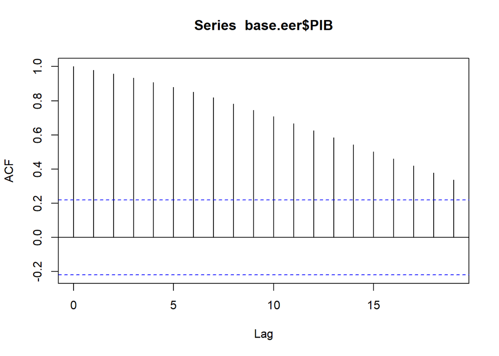

```r
acf(base.eer$PIB)
```

Outro método para identificar a presença de raiz unitária é realizarmos o chamado **teste de Dickey-Fuller**[^3] em que regredimos
$$y_t - y_{t - 1} = \gamma y_{t-1} + \epsilon_t$$
em que $\gamma = \phi - 1$ e temos como hipótese nula $H_0 : \gamma = 0$ e alternativa $H_a = \gamma < 0$. Como discutimos, sob $H_0$ a distribuição de $\gamma$ não segue a distribuição *t-student* e os teste de hipótese usuais não se aplicam, por isso Dickey e Fuller apresentam valores críticos para conduzirmos nossos testes. Caso nossa variável de interesse seja um modelo *auto regressivo* de ordem $p > 1$ ($AR(p)$), então nós podemos realizar o **teste aumentado de Dickey-Fuller** incluindo as defasagens da diferença da variável na forma:
$$\Delta y_t = \beta_0 + \gamma y_{t-1} + \delta_1 \Delta y_{t-1} + \delta_2 \Delta y_{t-2} + \cdots + \delta_p \Delta y_{t-p} + \omega_t$$
, em que as hipóteses nula e alternativa se mantêm as mesmas. Os testes de Dickey-Fuller estão presentes no pacote `urca`.

```r
install.packages("urca")
```

Nele podemos encontrar não apenas o teste de Dickey-Fuller usual, mas também o *Dikcey-Fuller Generalized Least Squares* (ADF-GLS), chamado por teste ERS em homenagem aos seus autores[^4], e o *KPSS*, que é diferente dos demais ao ter como hipótese nula a estacionariedade da série, ao invés da presença de raiz unitária[^5]. Vamos utilizar aqui apenas os testes de ADF e ADF-GLS, mas nos exercícios você poderá explorar outros. Como sabemos, pelos autores, que todas as séries apresentam raiz unitária, com exceção daquela dos investimentos públicos, faremos o teste de raiz unitária apenas para a variável do PIB, com a qual já estamos trabalhando.